# Data 607 - Final Project

Cameron Smith

12/4/2020

# Introduction

This project is focused on analyzing the relationship, if any, between quality of packaged ramen and where it is manufactured. I will start by looking at where the best ramen is made based on the average review score for each country, expanding and comparing that analysis from country to regions and assessing via a T-test whether the differences are statistically significant.

From there I will look at whether there is a relationship between proximity to Japan and average review score. To do this I will need to find the coordinates (latitude / longitude) for the location of each observation (i.e. country) and find a way to calculate distance between them, which will be a good opportunity to try some GIS-focused functions in R.

Lastly, I will create a map to visualize the data.

## Load Required Libraries

```r
library(tidyverse)
library(kableExtra)
library(countrycode)
library(cowplot)
library(raster)
library(CoordinateCleaner)
library(mapproj)
```

## Load Data

Load the dataset. The data is from Kaggle but I am loading it from my personal Github account to maximize reproducibility.

Formal citation for data set: Bilogur, A. (2018; January). Ramen Ratings, Version 1. Retrieved 22 November 2020 from https://www.kaggle.com/residentmario/ramen-ratings.

```r
# Load data from Github
url <- "https://raw.githubusercontent.com/cwestsmith/cuny-msds/master/datasets/ramen-ratings.csv"
rawdata <- read.csv(url, header=TRUE)

# Quick look at the data to make sure everything loaded ok
glimpse(rawdata)
```

```
## Rows: 2,580
## Columns: 7
## $ Review.. <int> 2580, 2579, 2578, 2577, 2576, 2575, 2574, 2573, 2572, 2571...
## $ Brand    <chr> "New Touch", "Just Way", "Nissin", "Wei Lih", "Ching's Sec...
## $ Variety  <chr> "T's Restaurant Tantanmen ", "Noodles Spicy Hot Sesame Spi...
## $ Style    <chr> "Cup", "Pack", "Cup", "Pack", "Pack", "Pack", "Cup", "Tray...
## $ Country  <chr> "Japan", "Taiwan", "USA", "Taiwan", "India", "South Korea"...
## $ Stars    <chr> "3.75", "1", "2.25", "2.75", "3.75", "4.75", "4", "3.75", ...
## $ Top.Ten  <chr> "", "", "", "", "", "", "", "", "", "", "", "", "", "", ""...
```

# Prep, Tidy and Explore

## Tidy and Transform

The data appears to be pretty tidy but there is a bit of transformation to be done in order to maximize its usefulness.

```r
# Create variable to store tidy / prepped data
tidydata <- rawdata

# Change "Stars" column to numeric so that it can be used for quantitative analysis
tidydata$Stars <- as.numeric(tidydata$Stars)

# Find NA values, which shows there are 3 rows.
tidydata %>% filter(is.na(Stars) == TRUE)
```

```
##   Review..         Brand                               Variety Style
## 1     2548        Ottogi Plain Instant Noodle No Soup Included  Pack
## 2     2458 Samyang Foods                            Sari Ramen  Pack
## 3     1587      Mi E-Zee                         Plain Noodles  Pack
##       Country Stars Top.Ten
## 1 South Korea    NA
## 2 South Korea    NA
## 3    Malaysia    NA
```

```r
# Remove the NA values
tidydata <- tidydata %>% drop_na(Stars)

# Check again for NA values, which confirms the 3 rows have been removed.
tidydata %>% filter(is.na(Stars) == TRUE)
```

```
## [1] Review.. Brand    Variety  Style    Country  Stars    Top.Ten
## <0 rows> (or 0-length row.names)
```

```r
# Add and calculate a variable for the region of each country
tidydata <- tidydata %>%
  mutate(Region = countrycode(sourcevar = tidydata$Country, origin = "country.name", destination = "region"))

# Check for NA values in the new column, which indicates issues for Sarawak, Holland and Dubai
tidydata %>% filter(is.na(Region) == TRUE)
```

```
##    Review..            Brand                                      Variety Style
## 1      1717      Lee Fah Mee           Sarawak White Laksa Instant Noodle  Pack
## 2      1708 The Kitchen Food                 Sibu Instant Kampua Original  Pack
## 3      1697 The Kitchen Food                Instant Kampua Dark Soy Sauce  Pack
## 4      1012             Unox Good Noodles Oosterse Kip (Oriental Chicken)  Pack
## 5       993             Unox                                         Sate  Pack
## 6       797       Golden Mie                                    Vegetable  Pack
## 7       742       Golden Mie                                      chicken  Pack
## 8       720       Golden Mie                                Chicken Curry  Pack
## 9       544             Unox                         Good Noodles Chicken  Pack
## 10      528             Unox                       Good Noodles Vegetable  Pack
##    Country Stars Top.Ten Region
## 1  Sarawak  4.00           <NA>
## 2  Sarawak  4.00           <NA>
## 3  Sarawak  5.00           <NA>
## 4  Holland  3.50           <NA>
## 5  Holland  3.50           <NA>
## 6    Dubai  3.75           <NA>
## 7    Dubai  3.25           <NA>
## 8    Dubai  3.75           <NA>
## 9  Holland  3.50           <NA>
## 10 Holland  3.75           <NA>
```

```r
# Update the mismatching country names accordingly
tidydata$Country <- gsub("Sarawak", "Malaysia", tidydata$Country, perl=TRUE)
tidydata$Country <- gsub("Holland", "Netherlands", tidydata$Country, perl=TRUE)
tidydata$Country <- gsub("Dubai", "United Arab Emirates", tidydata$Country, perl=TRUE)

# Also update other countries with name issues
tidydata$Country <- gsub("United\\sStates", "USA", tidydata$Country, perl=TRUE)

# Recalculate the region values using the updated country names
tidydata <- tidydata %>%
  mutate(Region = countrycode(sourcevar = tidydata$Country, origin = "country.name", destination = "region"))
```

## Explore the Data

Start with a quick look at various dimensions of the data to become familiar with it and see if anything stands out.

```r
# Summarise data per region, which indicates there are 7 different regions covered in the data set.
region_summary <- tidydata %>% dplyr::select(Region, Stars) %>% group_by(Region) %>% summarise(avg_stars = mean(Stars), num_rows = n())
region_summary
```

```
## # A tibble: 7 x 3
##   Region                     avg_stars num_rows
##   <chr>                          <dbl>    <int>
## 1 East Asia & Pacific             3.76     1973
## 2 Europe & Central Asia           3.17      136
## 3 Latin America & Caribbean       3.74       36
## 4 Middle East & North Africa      3.58        3
## 5 North America                   3.32      365
## 6 South Asia                      3.41       61
## 7 Sub-Saharan Africa              2.83        3
```

```r
ungroup(region_summary)
```

```
## # A tibble: 7 x 3
##   Region                     avg_stars num_rows
##   <chr>                          <dbl>    <int>
## 1 East Asia & Pacific             3.76     1973
## 2 Europe & Central Asia           3.17      136
## 3 Latin America & Caribbean       3.74       36
## 4 Middle East & North Africa      3.58        3
## 5 North America                   3.32      365
## 6 South Asia                      3.41       61
## 7 Sub-Saharan Africa              2.83        3
```

```r
# Sort by highest-scoring top 10 countries
country_summary <- tidydata %>% dplyr::select(Country, Stars) %>% group_by(Country) %>% summarise(avg_stars = mean(Stars), num_rows = n())
country_summary %>% arrange(desc(avg_stars)) %>%
  top_n(20)
```

```
## # A tibble: 21 x 3
##    Country     avg_stars num_rows
##    <chr>           <dbl>    <int>
##  1 Malaysia         4.16      158
##  2 Singapore        4.13      109
##  3 Indonesia        4.07      126
##  4 Japan            3.98      352
##  5 Myanmar          3.95       14
##  6 Hong Kong        3.80      137
##  7 South Korea      3.79      307
##  8 Mexico           3.73       25
##  9 Taiwan           3.67      224
## 10 Germany          3.64       27
## # ... with 11 more rows
```

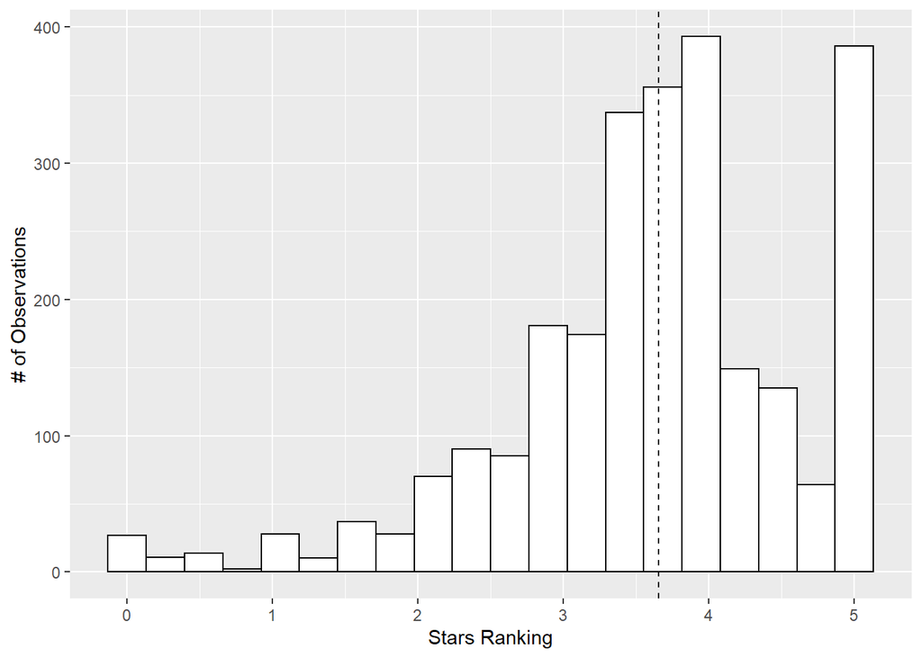

```r
# Histogram with mean line
p1 <- ggplot(tidydata, aes(Stars)) +
  geom_histogram(bins = 20, fill = "white", color = "black")  +
  geom_vline(aes(xintercept = mean(Stars)), linetype = 2) +
  xlab("Stars Ranking") + ylab("# of Observations")
p1
```

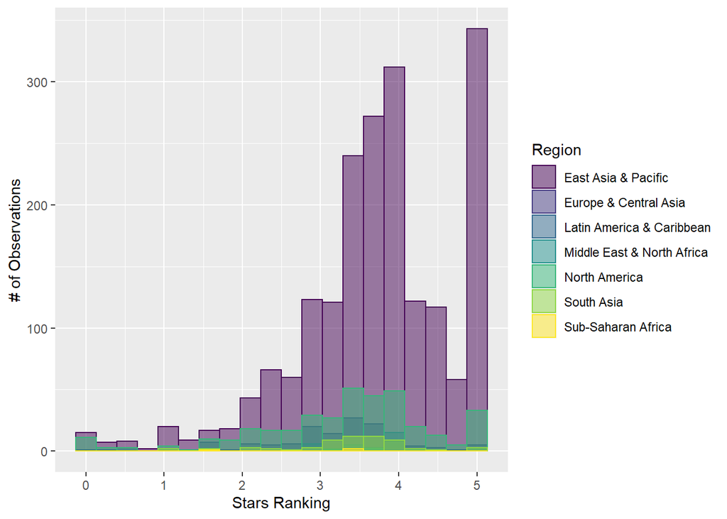

```r
# Histogram grouped by region
p2 <- ggplot(tidydata, aes(Stars)) +
  geom_histogram(aes(fill = Region, color = Region), bins = 20,
                position = "identity", alpha = 0.5) +
  scale_fill_viridis_d() +
  scale_color_viridis_d() +
  xlab("Stars Ranking") + ylab("# of Observations")
p2
```

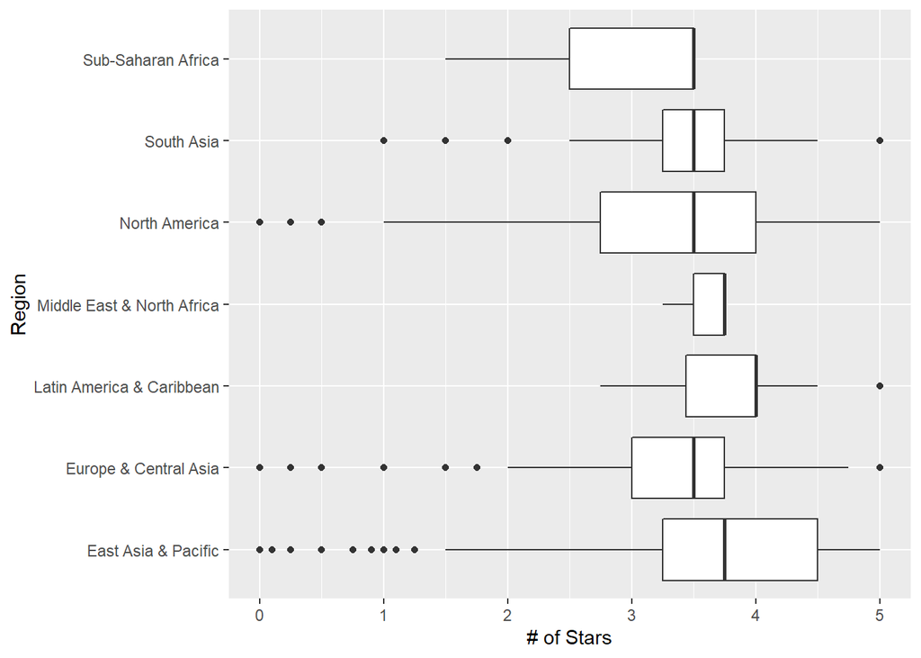

```r
# Box Plots grouped by region
p3 <- ggplot(tidydata, aes(x=Region, y=Stars)) +
  geom_boxplot() +
  coord_flip() +
  xlab("Region") + ylab("# of Stars")
p3
```

East Asia & Pacific has the highest average score, but is the difference statistically significant?

# Statistical Analysis

## Summary Statistics

```r
# First separate the data into groups
eap_only <- tidydata %>% filter(Region == "East Asia & Pacific")
eap_excluded <- tidydata %>% filter(Region != "East Asia & Pacific")

# View summary statistics
summary(eap_only$Stars)
```

```
##    Min. 1st Qu.  Median    Mean 3rd Qu.    Max.
##   0.000   3.250   3.750   3.757   4.500   5.000
```

```r
summary(eap_excluded$Stars)
```

```
##    Min. 1st Qu.  Median    Mean 3rd Qu.    Max.
##    0.00    3.00    3.50    3.32    4.00    5.00
```

## T-test

First analysis: using a one-sided T-test, is there a statistically significant difference?

**Null hypothesis:** The average reviews for “East Asia & Pacific” region are not higher than those from the rest of the world **Alternative hypothesis:** The average reviews for “East Asia & Pacific” region are higher than those from the rest of the world

Conditions for Inference:

- Independence, Extended: Assumed yes for this exercise, though not much is actually known re: the method of data collection
- Normality: With N of over 30 normality is assumed, though the box plots above and QQ Plots below do indicate some potential outliers

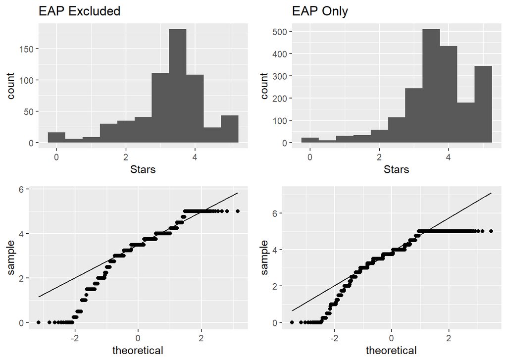

```r
# Histograms to check normality condition for both groups
p4 <- ggplot(data=eap_excluded, aes(Stars)) + geom_histogram(binwidth = .5) +
  ggtitle("EAP Excluded")
p5 <- ggplot(data=eap_only, aes(Stars)) + geom_histogram(binwidth = .5) +
  ggtitle("EAP Only")

# QQ plots to test normality of data for both groups
p6 <- ggplot(eap_excluded, aes(sample = Stars)) +
  stat_qq() +
  stat_qq_line()

p7 <- ggplot(eap_only, aes(sample = Stars)) +
  stat_qq() +
  stat_qq_line()

plot_grid(p4,
          p5,
          p6,
          p7,
          label_x = 0.2,
          ncol = 2)
```

Perform the T-test

```r
t.test(eap_only$Stars, eap_excluded$Stars, alternative = "greater")
```

```
##
##  Welch Two Sample t-test
##
## data:  eap_only$Stars and eap_excluded$Stars
## t = 9.0305, df = 941.18, p-value < 2.2e-16
## alternative hypothesis: true difference in means is greater than 0
## 95 percent confidence interval:
##  0.3571756       Inf
## sample estimates:
## mean of x mean of y
##  3.757058  3.320240
```

The p-value is 0, indicating based on a significant level of .05 (95% confidence) that the null hypothesis can be rejected in favor of the alternative hypothesis.

Ramen from EAP, based on this data, has a higher star rating (i.e. it subjectively ‘better’) than ramen from other regions.

So within the EAP region, where is the ‘best of the best’? Cambodia, Malaysia, and Singapore, it seems.

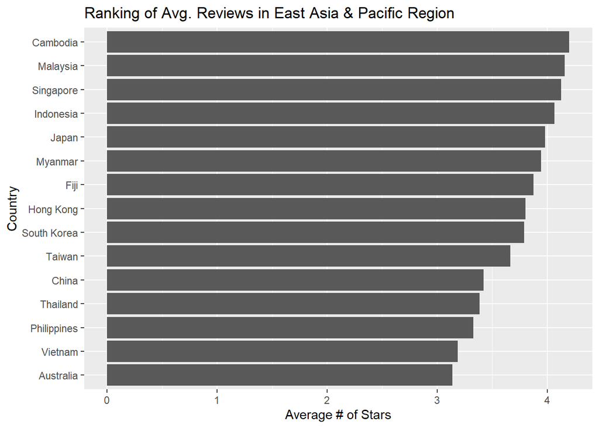

```r
eap_only_avg <- eap_only %>% dplyr::select(Variety, Country, Stars) %>% group_by(Country) %>% summarise(avg_stars = mean(Stars), num_rows = n())

eap_only_avg %>% ggplot(aes(x = reorder(Country, avg_stars), y = avg_stars)) +
    geom_bar(stat="identity") +
    coord_flip() +
  xlab("Country") + ylab("Average # of Stars") +
  ggtitle("Ranking of Avg. Reviews in East Asia & Pacific Region")
```

## Correlation: Proximity from Japan

Next let’s look at whether there is a correlation between average stars and the country’s proximity from Japan, which is often considered ramen’s ‘home’ (though interestingly I read it is actually from China originally).

First we need to add a column with the latitude and longitude. From there distances can be calculated and compared.

```r
# First have a look at countryref to see what is in there
glimpse(countryref)
```

```
## Rows: 5,305
## Columns: 13
## $ iso3                    <chr> "AFG", "AFG", "AFG", "ALA", "ALA", "ALB", "...
## $ iso2                    <chr> "AF", "AF", "AF", "AX", "AX", "AL", "AL", "...
## $ adm1_code               <fct> AFG, AFG, AFG, ALA, ALA, ALB, ALB, DZA, DZA...
## $ name                    <chr> "Afghanistan", "Afghanistan", "Afghanistan"...
## $ type                    <chr> "country", "country", "country", "country",...
## $ centroid.lon            <dbl> 65.000000, 66.000000, 65.216000, 19.952000,...
## $ centroid.lat            <dbl> 33.00000, 33.00000, 33.67700, 60.19800, 60....
## $ capital                 <fct> Kabul, Kabul, Kabul, NA, NA, Tirana, Tirana...
## $ capital.lon             <dbl> 69.18, 69.18, 69.18, NA, NA, 19.82, 19.82, ...
## $ capital.lat             <dbl> 34.52, 34.52, 34.52, NA, NA, 41.32, 41.32, ...
## $ area_sqkm               <dbl> 6.421816e+05, 6.421816e+05, 6.421816e+05, N...
## $ uncertaintyRadiusMeters <chr> "301", "301", NA, NA, NA, "301", NA, "301",...
## $ source                  <chr> "geolocate", "geolocate", NA, NA, NA, "geol...
```

```r
# Create new data frame with needed columns
country_geoinfo <- countryref %>% dplyr::select(name, centroid.lon, centroid.lat)
# Rename the country name column so that the join will work
colnames(country_geoinfo)[1] = "Country"

# There are multiple rows with different geolocations.  Need to get rid of duplicates for join
temp <- ""
newgeoinfo <- data.frame(Country = character(), longitude = numeric(), latitude = numeric())
counter <- 0
rowcounter <- 0

for (i in 1:nrow(country_geoinfo)) {
  counter <- counter + 1
  ifelse(counter == 1, temp <- country_geoinfo[counter,1], temp <- country_geoinfo[counter-1,1])
  ifelse(country_geoinfo[counter, 1] == temp, discard <- 1, newgeoinfo[counter,] <- country_geoinfo[counter,])
}

# Update the names of countries that do not match our original data frame
newgeoinfo$Country <- gsub("Hong\\sKong\\sSAR\\sChina", "Hong Kong", newgeoinfo$Country, perl=TRUE)
newgeoinfo$Country <- gsub("United\\sStates", "USA", newgeoinfo$Country, perl=TRUE)
newgeoinfo$Country <- gsub("Myanmar\\s\\(Burma\\)", "Myanmar", newgeoinfo$Country, perl=TRUE)
newgeoinfo$Country <- gsub("United Kingdom", "UK", newgeoinfo$Country, perl=TRUE)

# Use new data frame with one row per country for a join to add longitude / latitude to original data frame
country_summary <- left_join(country_summary, newgeoinfo, by = "Country")

# Find and store coordinates for Japan
japancoords <- country_summary %>% filter(Country == "Japan") %>% dplyr::select(longitude, latitude)
country_summary$distance_japan <- as.numeric("")

counter2 <- 0
for (j in 1:nrow(country_summary)) {
  counter2 <- counter2 + 1
  country_summary$distance_japan[counter2] <- pointDistance(c(country_summary$longitude[counter2],country_summary$latitude[counter2]), japancoords, lonlat = TRUE)
}

# Is there a correlation between score and distance to Japan?  It seems not.
cor.test(country_summary$avg_stars, country_summary$distance_japan, method = "pearson")
```

```
##
##  Pearson's product-moment correlation
##
## data:  country_summary$avg_stars and country_summary$distance_japan
## t = -1.563, df = 35, p-value = 0.127
## alternative hypothesis: true correlation is not equal to 0
## 95 percent confidence interval:
##  -0.53516200  0.07477118
## sample estimates:
##        cor
## -0.2554363
```

With a p-value of over .05 it seems the correlation, if any, if not significant.

## Map of Data

To finish, here is a map showing the average ramen review scores per country.

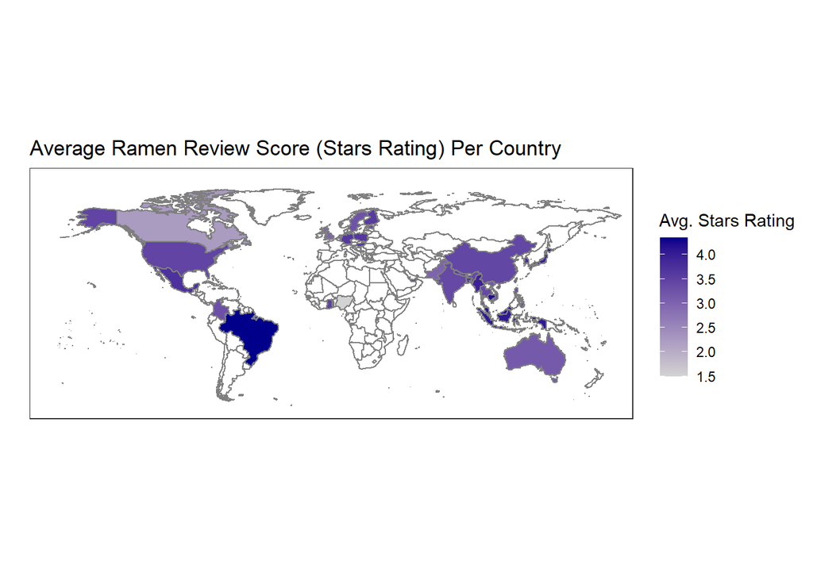

```r
WorldData <- map_data('world') %>% filter(region != "Antarctica") %>% fortify

df <- data.frame(region=country_summary$Country,
                 value=country_summary$avg_stars,
                 stringsAsFactors=FALSE)

p <- ggplot() +
    geom_map(data = WorldData, map = WorldData,
                  aes(x = long, y = lat, group = group, map_id=region),
                  fill = "white", colour = "#7f7f7f", size=0.5) +
    geom_map(data = df, map=WorldData,
                  aes(fill=value, map_id=region),
                  colour="#7f7f7f", size=0.5) +
    coord_map("rectangular", lat0=0, xlim=c(-180,180), ylim=c(-60, 90)) +
    scale_fill_continuous(low="lightgrey", high="darkblue", guide="colorbar") +
    scale_y_continuous(breaks=c()) +
    scale_x_continuous(breaks=c()) +
    labs(fill="Avg. Stars Rating", title="Average Ramen Review Score (Stars Rating) Per Country", x="", y="") +
    theme_bw()
p
```

# Conclusion

Not very surprisingly given its origins, the ‘best’ ramen seems to come from the East Asia & Pacific Region. Using a t-test the difference in means (EAP region versus rest of the world) can be inferred beyond the sample. That being said, this dataset was more focused on fun than science, and I would be reluctant to use this analysis beyond the scope of the project due mainly to the unknowns regarding independence of the sample.

Somewhat surprisingly to me, the ‘best’ packaged ramen is not from Japan. In fact, Japan barely makes the top 5. Not as surprisingly - but somewhat interestingly - there does not seem to be a correlation between proximity to Japan and quality of ramen.